# Python_Day_1_Exercises_Master

By the end of the exercises, you will be able to:

- Specifically extract digits from numbers using floor division and modulus to sum or reverse digits.
- Measure and calculate areas and distances applying appropriate formulas.
- Accept user input and convert temperature units accurately.
- Report results clearly using formatted output statements.
- Troubleshoot simple arithmetic operations in Python independently.

### 1) You are developing a simple reception desk system for a community centre. When a visitor arrives, the system needs to log their info and age to offer them a personalised greeting and direct them to suitable activities.

🧪 Task: Write a Python program that asks the visitor for their name and age, then prints a friendly greeting such as:

"Hello Sarah, welcome to the Community Centre! At 25, you're eligible for our young adults programme."

```python
name=input("Digit your name: ")
age=int(input("Digit your age: "))
print(f"Hello {name}, welcome to the Community Centre! At {age}, you're eligible for our young adults programme.")
```

```
Digit your name: Gaspare
Digit your age: 50
Hello Gaspare, welcome to the Community Centre! At 50, you're eligible for our young adults programme.
```

### 2) You work for a home renovation company that installs floor tiles. A customer wants to tile their kitchen floor and needs to know how many square meters of tiles to buy.

🧪 Task: Write a Python program that asks the customer for the length and width of their kitchen (in meters), then calculates and displays the total area that needs to be tiled.

💬 Example Output: "To tile a kitchen of 3.5m x 2.8m, you will need 9.8 square meters of tiles."

🎯 Bonus Challenge: Each tile costs £12 per square meter. Add a cost calculator. Format the final message to include both the total area and the total cost:

"You will need 9.8 square meters of tiles. The total cost will be £117.60.

```python
width=float(input("Digit your width: "))
length=float(input("Digit your length: "))
total_area=width*length
cost=total_area*12
print(f"To tile a kitchen of {width}m x {length}m, you will need {total_area} square meters of tiles. The total cost will be £{cost}" ,end=".")
```

```
Digit your width: 3.5
Digit your length: 2.8
To tile a kitchen of 3.5m x 2.8m, you will need 9.799999999999999 square meters of tiles. The total cost will be £117.6.
```

### 3) You’re helping build a basic weather app for travellers. One feature allows users to see today’s temperature in either Celsius or Fahrenheit, depending on their preference.

🧪 Task: Write a Python program that asks the user for today's temperature in Celsius, then converts it to Fahrenheit using the formula: Then print the converted temperature in a user-friendly sentence.

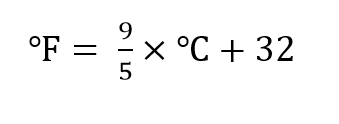

```python
celsius = float(input("Enter today's temperature in Celsius: "))
fahrenheit = (celsius * 9/5) + 32
print(f"Today's temperature of {celsius}°C equals {fahrenheit:.1f}°F.")
```

```
Enter today's temperature in Celsius: 45.9
Today's temperature of 45.9°C equals 114.6°F.
```

### 4) You are helping design a basic travel guide that helps users convert distances between miles and kilometres. For now, your app will do one conversion at a time, depending on which version of the program they run.

✨ Version A: Convert Miles to Kilometres 🧪 Task: Write a Python program that: Asks the user to enter a distance in miles Converts it to kilometres using the formula: **km=miles×1.60934**

Prints the converted distance.

✨ Version B: Convert Kilometres to Miles 🧪 Task: Write a Python program that: Asks the user to enter a distance in kilometres Converts it to miles using the formula: **miles=km÷1.60934**

Prints the converted distance.

```python
miles=float(input("Write your distance in miles: "))
km=miles*1.60934
print(f"{km} km")
```

```
Write your distance in miles: 56
90.12304 km
```

```python
km=float(input("Write your distance in km: "))
miles=km/1.60934
print(f"{miles} miles")
```

[output not shown]

### 5) You’re helping a theme park design a fun feature for visitors. When they enter a 3-digit number, your program will add the digits together to tell them their "lucky number."

🧪 Task: Write a Python program that: Asks the user to enter a 3-digit number

Separates the hundreds, tens, and units digits using floor division (//) and modulus (%)

Adds the digits together

Prints the result as their "lucky number"

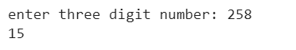

```python
number = int(input("Enter a 3-digit number: "))
hundreds = number // 100
tens = (number // 10) % 10
units = number % 10
lucky_number = hundreds + tens + units
print(f"Your lucky number is: {lucky_number}")
```

```
Enter a 3-digit number: 769
Your lucky number is: 22
```

### 6) You’re helping a museum design an escape room game. When players find a 4-digit number, they must reverse it using your program to unlock the next clue.

🧪 Task: Write a Python program that:

Asks the user to enter a 4-digit number

Uses floor division (//) and modulus (%) to separate the digits

Reverses the digits and prints the result as the “secret code

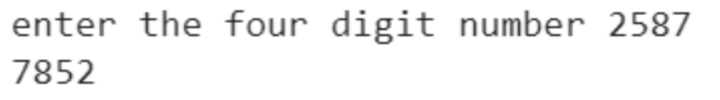

```python
number=input("Digit 4 numbers:")
reversed_number = number[::-1]
print(f"The secret code is: {reversed_number}")
```

```
Digit 4 numbers:2587
The secret code is: 7852
```